# LikertMakeR vignette

## Create a dataframe for a t-test

Generating a data for an **independent-samples t-test** is trivial with *LikertMakeR*. But a dataframe for a **paired-sample t-test** is tricky because the observations are related to each other. That is, we must generate a dataframe of correlated observations.

### Independent-samples t-test

Note that such tests don’t even require the same sample-size.

```r
## define parameters
lower <- 1
upper <- 5
items <- 6

## generate two independent samples
x1 <- lfast(
  n = 20, mean = 2.5, sd = 0.75,
  lowerbound = lower, upperbound = upper, items = items
)
```

```
#> reached maximum of 1024 iterations
```

```r
x2 <- lfast(
  n = 30, mean = 3.0, sd = 0.85,
  lowerbound = lower, upperbound = upper, items = items
)
```

```
#> reached maximum of 1024 iterations
```

```r
## run independent-samples t-test
t.test(x1, x2)
```

```
#>
#>  Welch Two Sample t-test
#>
#> data:  x1 and x2
#> t = -2.1599, df = 44.101, p-value = 0.03626
#> alternative hypothesis: true difference in means is not equal to 0
#> 95 percent confidence interval:
#>  -0.95576930 -0.03311959
#> sample estimates:
#> mean of x mean of y
#>  2.500000  2.994444
```

### makePaired() paired-sample t-test

**makePaired()** generates correlated values so the data replicate rating scales taken, for example, in a before and after experimental design. The function is effectively a wrapper function for *lfast()* and *lcor()* with the addition of a *t-statistic* from which the between-column correlation is inferred.

Paired t-tests apply to observations that are associated with each other. For example: the same people rating the same object before and after a treatment, the same people rating two different objects, ratings by husband & wife, *etc.*

**makePaired()** has similar parameters as for the *lfast()* function with the addition of a value for the desired t-statistic.

- **n** sample size
- **means** a [1:2] vector of target means for two before/after measures
- **sds** a [1:2] vector of target standard deviations
- **t_value** desired paired t-statistic
- **lowerbound** lower bound (e.g. ‘1’ for a 1-5 rating scale)
- **upperbound** upper bound (e.g. ‘5’ for a 1-5 rating scale)
- **items** number of items in the rating scale.
- **precision** can relax the level of accuracy required, as in *lfast()*.

### makePaired() examples

```r
## define parameters
n <- 20
means <- c(2.5, 3.0)
sds <- c(0.75, 0.85)
lower <- 1
upper <- 5
items <- 6
t <- -2.5

## run the function
pairedDat <- makePaired(
  n = n, means = means, sds = sds,
  t_value = t,
  lowerbound = lower, upperbound = upper, items = items
)
```

```
#> Initial data vectors
#> reached maximum of 1024 iterations
#> reached maximum of 1024 iterations
#> Rearrange values to conform with desired t-value
#> Complete!
```

###### check properties of new data

```r
## test function output
str(pairedDat)
```

```
#> 'data.frame':    20 obs. of  2 variables:
#>  $ X1: num  1.17 3.5 3.33 3.67 3.17 ...
#>  $ X2: num  2.67 3.67 3.5 3.5 4 ...
```

```r
cor(pairedDat) |> round(2)
```

```
#>      X1   X2
#> X1 1.00 0.38
#> X2 0.38 1.00
```

```r
pairedMoments <- data.frame(
  mean = apply(pairedDat, MARGIN = 2, FUN = mean) |> round(3),
  sd = apply(pairedDat, MARGIN = 2, FUN = sd) |> round(3)
) |> t()

pairedMoments
```

```
#>         X1    X2
#> mean 2.500 2.992
#> sd   0.759 0.851
```

###### run a paired-sample t-test with the new data

```r
## run a paired-sample t-test
paired_t <- t.test(x = pairedDat$X1, y = pairedDat$X2, paired = TRUE)

paired_t
```

```
#>
#>  Paired t-test
#>
#> data:  pairedDat$X1 and pairedDat$X2
#> t = -2.4455, df = 19, p-value = 0.02438
#> alternative hypothesis: true mean difference is not equal to 0
#> 95 percent confidence interval:
#>  -0.91246509 -0.07086825
#> sample estimates:
#> mean difference
#>      -0.4916667
```

## Create a multidimensional dataframe of correlated scale items

### correlateScales()

Correlated rating-scale items generally are summed or averaged to create a measure of an “unobservable”, or “latent”, construct.

**correlateScales()** takes several such dataframes of rating-scale items and rearranges their rows so that the scales are correlated according to a predefined correlation matrix. Univariate statistics for each dataframe of rating-scale items do not change, but their correlations with rating-scale items in other dataframes do.

To run **correlateScales()**, parameters are:

- **dataframes**: a list of ‘k’ dataframes to be rearranged and combined
- **scalecors**: target correlation matrix - should be a symmetric k*k positive-semi-definite matrix, where ‘k’ is the number of dataframes

As with other functions in *LikertMakeR*, *correlateScales()* focuses on item and scale moments (mean and standard deviation) rather than on covariance structure. If you wish to simulate data for teaching or experimenting with Structural Equation modelling, then I recommend the *sim.item()* and *sim.congeneric()* functions from the [psych package](https://CRAN.R-project.org/package=psych)

### correlateScales() examples

#### three attitudes and a behavioural intention

##### create dataframes of Likert-scale items

```r
n <- 128
lower <- 1
upper <- 5

### attitude #1

#### generate a correlation matrix
cor_1 <- makeCorrAlpha(items = 4, alpha = 0.80)
```

```
#> correlation values consistent with desired alpha in 8915 iterations
#> The correlation matrix is positive definite
```

```r
#### specify moments as vectors
means_1 <- c(2.5, 2.5, 3.0, 3.5)
sds_1 <- c(0.75, 0.85, 0.85, 0.75)

#### apply makeItems() function
Att_1 <- makeItems(
  n = n, means = means_1, sds = sds_1,
  lowerbound = rep(lower, 4), upperbound = rep(upper, 4),
  cormatrix = cor_1
)
```

```
#> Variable  1
#> reached maximum of 16384 iterations
#> Variable  2
#> best solution in 2787 iterations
#> Variable  3
#> best solution in 56 iterations
#> Variable  4
#> reached maximum of 16384 iterations
#>
#> Arranging data to match correlations
#>
#> Successfully generated correlated variables
```

```r
### attitude #2

#### generate a correlation matrix
cor_2 <- makeCorrAlpha(items = 5, alpha = 0.85)
```

```
#> correlation values consistent with desired alpha in 9433 iterations
#> The correlation matrix is positive definite
```

```r
#### specify moments as vectors
means_2 <- c(2.5, 2.5, 3.0, 3.0, 3.5)
sds_2 <- c(0.75, 0.85, 0.75, 0.85, 0.75)

#### apply makeItems() function
Att_2 <- makeItems(
  n, means_2, sds_2,
  rep(lower, 5), rep(upper, 5),
  cor_2
)
```

```
#> Variable  1
#> reached maximum of 16384 iterations
#> Variable  2
#> best solution in 1284 iterations
#> Variable  3
#> reached maximum of 16384 iterations
#> Variable  4
#> best solution in 334 iterations
#> Variable  5
#> reached maximum of 16384 iterations
#>
#> Arranging data to match correlations
#>
#> Successfully generated correlated variables
```

```r
### attitude #3

#### generate a correlation matrix
cor_3 <- makeCorrAlpha(items = 6, alpha = 0.90)
```

```
#> correlation values consistent with desired alpha in 37872 iterations
#> The correlation matrix is positive definite
```

```r
#### specify moments as vectors
means_3 <- c(2.5, 2.5, 3.0, 3.0, 3.5, 3.5)
sds_3 <- c(0.75, 0.85, 0.85, 1.0, 0.75, 0.85)

#### apply makeItems() function
Att_3 <- makeItems(
  n, means_3, sds_3,
  rep(lower, 6), rep(upper, 6),
  cor_3
)
```

```
#> Variable  1
#> reached maximum of 16384 iterations
#> Variable  2
#> best solution in 461 iterations
#> Variable  3
#> best solution in 149 iterations
#> Variable  4
#> reached maximum of 16384 iterations
#> Variable  5
#> reached maximum of 16384 iterations
#> Variable  6
#> best solution in 1779 iterations
#>
#> Arranging data to match correlations
#>
#> Successfully generated correlated variables
```

```r
### behavioural intention
intent <- lfast(n, mean = 4.0, sd = 3, lowerbound = 0, upperbound = 10) |>
  data.frame()
```

```
#> reached maximum of 16384 iterations
```

```r
names(intent) <- "int"
```

###### check properties of item dataframes

```r
## Attitude #1
A1_moments <- data.frame(
  means = apply(Att_1, 2, mean) |> round(2),
  sds = apply(Att_1, 2, sd) |> round(2)
) |> t()

### Attitude #1 moments
A1_moments
```

```
#>       [,1] [,2] [,3] [,4]
#> means 2.50 2.50 3.00 3.50
#> sds   0.75 0.85 0.85 0.75
```

```r
### Attitude #1 correlations
cor(Att_1) |> round(2)
```

```
#>      [,1] [,2] [,3] [,4]
#> [1,] 1.00 0.20 0.42 0.49
#> [2,] 0.20 1.00 0.55 0.57
#> [3,] 0.42 0.55 1.00 0.79
#> [4,] 0.49 0.57 0.79 1.00
```

```r
### Attitude #1 cronbach's alpha
alpha(cor(Att_1)) |> round(3)
```

```
#> [1] 0.801
```

```r
## Attitude #2
A2_moments <- data.frame(
  means = apply(Att_2, 2, mean) |> round(2),
  sds = apply(Att_2, 2, sd) |> round(2)
) |> t()

### Attitude #2 moments
A2_moments
```

```
#>       [,1] [,2] [,3] [,4] [,5]
#> means 2.50 2.50 3.00 3.00 3.50
#> sds   0.75 0.85 0.75 0.85 0.75
```

```r
### Attitude #2 correlations
cor(Att_2) |> round(2)
```

```
#>      [,1] [,2] [,3] [,4] [,5]
#> [1,] 1.00 0.31 0.32 0.33 0.50
#> [2,] 0.31 1.00 0.53 0.54 0.58
#> [3,] 0.32 0.53 1.00 0.71 0.71
#> [4,] 0.33 0.54 0.71 1.00 0.77
#> [5,] 0.50 0.58 0.71 0.77 1.00
```

```r
### Attitude #2 cronbach's alpha
alpha(cor(Att_2)) |> round(3)
```

```
#> [1] 0.849
```

```r
## Attitude #3
A3_moments <- data.frame(
  means = apply(Att_3, 2, mean) |> round(2),
  sds = apply(Att_3, 2, sd) |> round(2)
) |> t()

### Attitude #3 moments
A3_moments
```

```
#>       [,1] [,2] [,3] [,4] [,5] [,6]
#> means 2.50 2.50 3.00    3 3.50 3.50
#> sds   0.75 0.85 0.85    1 0.75 0.85
```

```r
### Attitude #3 correlations
cor(Att_3) |> round(2)
```

```
#>      [,1] [,2] [,3] [,4] [,5] [,6]
#> [1,] 1.00 0.31 0.37 0.40 0.43 0.43
#> [2,] 0.31 1.00 0.53 0.61 0.63 0.71
#> [3,] 0.37 0.53 1.00 0.72 0.72 0.74
#> [4,] 0.40 0.61 0.72 1.00 0.75 0.80
#> [5,] 0.43 0.63 0.72 0.75 1.00 0.84
#> [6,] 0.43 0.71 0.74 0.80 0.84 1.00
```

```r
### Attitude #2 cronbach's alpha
alpha(cor(Att_3)) |> round(3)
```

```
#> [1] 0.899
```

```r
## Behavioural Intention

intent_moments <- data.frame(
  mean = apply(intent, 2, mean) |> round(3),
  sd = apply(intent, 2, sd) |> round(3)
) |> t()

### Intention moments
intent_moments
```

```
#>        int
#> mean 4.000
#> sd   3.004
```

##### correlateScales parameters

```r
### target scale correlation matrix
scale_cors <- matrix(
  c(
    1.0, 0.7, 0.6, 0.5,
    0.7, 1.0, 0.4, 0.3,
    0.6, 0.4, 1.0, 0.2,
    0.5, 0.3, 0.2, 1.0
  ),
  nrow = 4
)

### bring dataframes into a list
data_frames <- list("A1" = Att_1, "A2" = Att_2, "A3" = Att_3, "Int" = intent)
```

#### apply the correlateScales() function

```r
### apply correlateScales() function
my_correlated_scales <- correlateScales(
  dataframes = data_frames,
  scalecors = scale_cors
)
```

```
#> scalecors  is positive-definite
#> New dataframe successfully created
```

#### plot the new correlated scale items

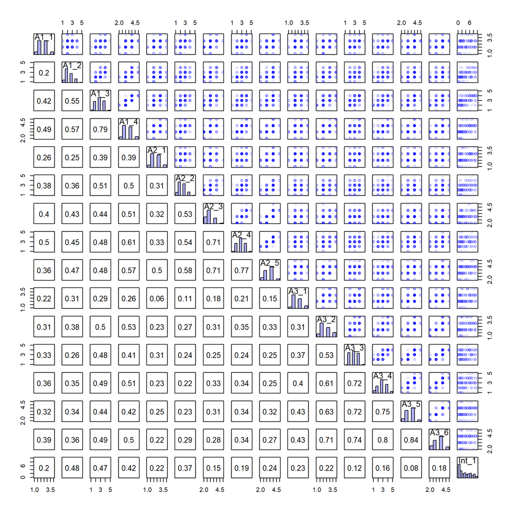

###### Check the properties of our derived dataframe

```r
## data structure
str(my_correlated_scales)
```

```
#> 'data.frame':    128 obs. of  16 variables:
#>  $ A1_1 : num  1 2 3 4 3 2 3 2 3 2 ...
#>  $ A1_2 : num  2 4 3 3 2 3 1 4 3 2 ...
#>  $ A1_3 : num  2 3 5 4 3 4 2 3 3 3 ...
#>  $ A1_4 : num  3 4 5 5 4 4 3 4 4 3 ...
#>  $ A2_1 : num  2 3 4 3 3 3 2 3 3 3 ...
#>  $ A2_2 : num  1 4 4 3 3 4 2 2 3 2 ...
#>  $ A2_3 : num  2 4 5 3 4 4 2 3 3 3 ...
#>  $ A2_4 : num  1 4 4 4 4 4 3 3 3 3 ...
#>  $ A2_5 : num  3 5 4 4 4 4 3 3 3 4 ...
#>  $ A3_1 : num  1 2 4 2 2 2 2 2 2 3 ...
#>  $ A3_2 : num  2 3 4 4 2 2 3 2 3 4 ...
#>  $ A3_3 : num  2 3 5 3 3 2 4 2 4 4 ...
#>  $ A3_4 : num  2 3 5 2 4 2 3 3 3 4 ...
#>  $ A3_5 : num  3 4 5 4 4 3 4 2 4 3 ...
#>  $ A3_6 : num  2 4 5 4 4 3 4 3 4 4 ...
#>  $ Int_1: num  4 10 5 10 7 4 1 6 6 6 ...
```

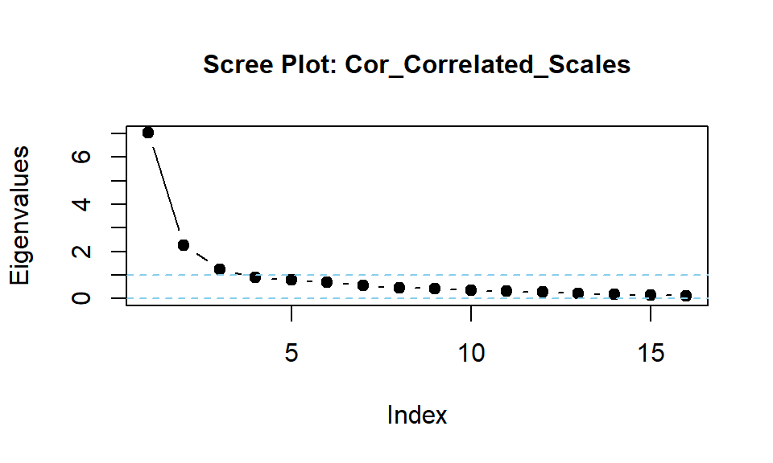

```
#> Cor_Correlated_Scales  is positive-definite
#>  [1] 7.03 2.28 1.24 0.90 0.78 0.71 0.57 0.46 0.43 0.34 0.31 0.27 0.22 0.17 0.16
#> [16] 0.12
```

```r
## eigenvalues of dataframe correlations
Cor_Correlated_Scales <- cor(my_correlated_scales)
eigenvalues(cormatrix = Cor_Correlated_Scales, scree = TRUE) |> round(2)
```

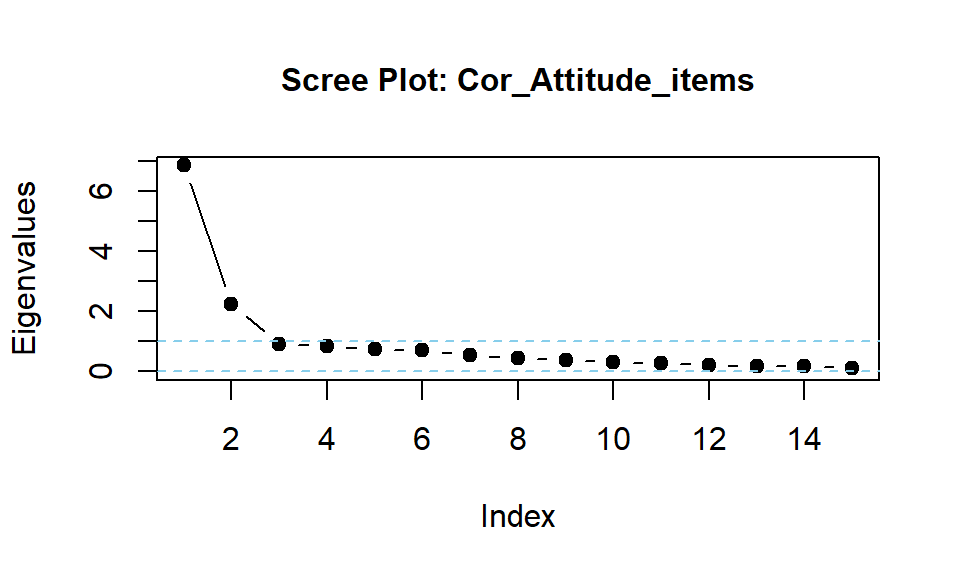

```
#> Cor_Attitude_items  is positive-definite
#>  [1] 6.88 2.24 0.92 0.86 0.74 0.70 0.55 0.45 0.39 0.31 0.27 0.23 0.17 0.16 0.13
```

```r
#### Eigenvalues of predictor variable items only
Cor_Attitude_items <- cor(my_correlated_scales[, -16])
eigenvalues(cormatrix = Cor_Attitude_items, scree = TRUE) |> round(2)
```

## Helper functions

*likertMakeR()* includes two additional functions that may be of help when examining parameters and output.

- *alpha()* calculates Cronbach’s Alpha from a given correlation matrix or a given dataframe
- *eigenvalues()* calculates eigenvalues of a correlation matrix, a report on whether the correlation matrix is positive definite, and produces an optional scree plot.

### alpha()

*alpha()* accepts, as input, either a correlation matrix or a dataframe. If both are submitted, then the correlation matrix is used by default, with a message to that effect.

### alpha() examples

```r
## define parameters
df <- data.frame(
  V1 = c(4, 2, 4, 3, 2, 2, 2, 1),
  V2 = c(3, 1, 3, 4, 4, 3, 2, 3),
  V3 = c(4, 1, 3, 5, 4, 1, 4, 2),
  V4 = c(4, 3, 4, 5, 3, 3, 3, 3)
)

corMat <- matrix(
  c(
    1.00, 0.35, 0.45, 0.75,
    0.35, 1.00, 0.65, 0.55,
    0.45, 0.65, 1.00, 0.65,
    0.75, 0.55, 0.65, 1.00
  ),
  nrow = 4, ncol = 4
)

## apply function examples
alpha(cormatrix = corMat)
```

```
#> [1] 0.8395062
```

```r
alpha(data = df)
```

```
#> [1] 0.8026658
```

```r
alpha(NULL, df)
```

```
#> [1] 0.8026658
```

```r
alpha(corMat, df)
```

```
#> Alert:
#> Both cormatrix and data present.
#>
#> Using cormatrix by default.
#> [1] 0.8395062
```

### eigenvalues()

*eigenvalues()* calculates eigenvalues of a correlation matrix, reports on whether the matrix is positive-definite, and optionally produces a scree plot.

### eigenvalues() examples

```r
## define parameters
correlationMatrix <- matrix(
  c(
    1.00, 0.25, 0.35, 0.45,
    0.25, 1.00, 0.70, 0.75,
    0.35, 0.70, 1.00, 0.85,
    0.45, 0.75, 0.85, 1.00
  ),
  nrow = 4, ncol = 4
)

## apply function
evals <- eigenvalues(cormatrix = correlationMatrix)
```

```
#> correlationMatrix  is positive-definite
```

```r
print(evals)
```

```
#> [1] 2.7484991 0.8122627 0.3048151 0.1344231
```

##### eigenvalues() function with optional scree plot

```r
evals <- eigenvalues(correlationMatrix, 1)
```

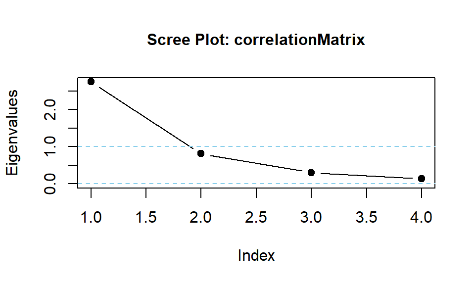

```
#> correlationMatrix  is positive-definite
print(evals)
#> [1] 2.7484991 0.8122627 0.3048151 0.1344231
```

# Alternative methods & packages

*LikertMakeR* is intended for synthesising & correlating rating-scale data with means, standard deviations, and correlations as close as possible to predefined parameters. If you don’t need your data to be close to exact, then other options may be faster or more flexible.

Different approaches include:

- sampling from a *truncated normal* distribution
- sampling with a predetermined probability distribution
- marginal model specification

### sampling from a *truncated normal* distribution

Data are sampled from a normal distribution, and then truncated to suit the rating-scale boundaries, and rounded to set discrete values as we see in rating scales.

See [Heinz (2021)](https://glaswasser.github.io/simulating-correlated-likert-scale-data/) for an excellent and short example using the following packages:

- truncnorm
- faux
- See also the *rLikert()* function from the excellent latent2likert package, [Lalovic (2024)](https://latent2likert.lalovic.io/), for an approach using optimal discretization and skew-normal distribution. *latent2likert()* converts continuous latent variables into ordinal categories to generate Likert scale item responses.

### sampling with a predetermined probability distribution

- the following code will generate a vector of values with approximately the given probabilities. Good for simulating a single item.

```r
n <- 128
sample(1:5, n,
  replace = TRUE,
  prob = c(0.1, 0.2, 0.4, 0.2, 0.1)
)
```

### marginal model specification

Marginal model specification extends the idea of a predefined probability distribution to multivariate and correlated dataframes.

- [SimCorrMix: Simulation of Correlated Data with Multiple Variable Types Including Continuous and Count Mixture Distributions](https://CRAN.R-project.org/package=SimCorrMix) on CRAN.
- [SimMultiCorrData: Simulation of Correlated Data with Multiple Variable Types](https://CRAN.R-project.org/package=SimMultiCorrData) on CRAN.
- [lsasim: Functions to Facilitate the Simulation of Large Scale Assessment Data](https://CRAN.R-project.org/package=lsasim) on CRAN. See [Matta et al. (2018)](https://doi.org/10.1186/s40536-018-0068-8)
- [GenOrd:Simulation of Discrete Random Variables with Given Correlation Matrix and Marginal Distributions](https://CRAN.R-project.org/package=GenOrd) on CRAN.
- [SimCorMultRes: Simulates Correlated Multinomial Responses](https://cran.r-project.org/package=SimCorMultRes) on CRAN. See [Touloumis (2016)](https://journal.r-project.org/archive/2016/RJ-2016-034/index.html)
- [covsim: VITA, IG and PLSIM Simulation for Given Covariance and Marginals](https://cran.r-project.org/package=covsim) on CRAN. See [Grønneberg et al. (2022)](https://www.jstatsoft.org/article/view/v102i03)

### Factor Models: Classical Test Theory (CTT)

The [psych package](https://CRAN.R-project.org/package=psych) has several excellent functions for simulating rating-scale data based on factor loadings.  
These focus on factor and item correlations rather than item moments.  
Highly recommended.

- [*psych::sim.item* Generate simulated data structures for circumplex, spherical, or simple structure](https://CRAN.R-project.org/package=psych)
- [*psych::sim.congeneric* Simulate a congeneric data set with or without minor factors](https://CRAN.R-project.org/package=psych) See [Revelle (in prep)](https://personality-project.org/r/book/)

Also:

[*simsem*](https://CRAN.R-project.org/package=simsem) has many functions for simulating and testing data for application in Structural Equation modelling. See examples at https://simsem.org/

### General data simulation

[*simpr*](https://CRAN.R-project.org/package=simpr) provides a general, simple, and tidyverse-friendly framework for generating simulated data, fitting models on simulations, and tidying model results.

# References

D’Alessandro, S., H. Winzar, B. Lowe, Ba.J. Babin, W. Zikmund (2020). *Marketing Research* 5<sup>ed</sup>, Cengage Australia. https://cengage.com.au/sem121/marketing-research-5th-edition-dalessandro-babin-zikmund

Grønneberg, S., Foldnes, N., & Marcoulides, K. M. (2022). covsim: An R Package for Simulating Non-Normal Data for Structural Equation Models Using Copulas. *Journal of Statistical Software*, 102(1), 1–45. doi:10.18637/jss.v102.i03

Heinz, A. (2021), Simulating Correlated Likert-Scale Data In R: 3 Simple Steps (blog post) https://glaswasser.github.io/simulating-correlated-likert-scale-data/

Lalovic M (2024). latent2likert: Converting Latent Variables into Likert Scale Responses. R package version 1.2.2, https://latent2likert.lalovic.io/.

Matta, T.H., Rutkowski, L., Rutkowski, D. & Liaw, Y.L. (2018), lsasim: an R package for simulating large-scale assessment data. *Large-scale Assessments in Education* 6, 15. doi:10.1186/s40536-018-0068-8

Pornprasertmanit, S., Miller, P., & Schoemann, A. (2021). simsem: R package for simulated structural equation modeling https://simsem.org/

Revelle, W. (in prep) *An introduction to psychometric theory with applications in R*. Springer. (working draft available at https://personality-project.org/r/book/ )

Touloumis, A. (2016), Simulating Correlated Binary and Multinomial Responses under Marginal Model Specification: The SimCorMultRes Package, *The R Journal* 8:2, 79-91. doi:10.32614/RJ-2016-034